# Practice 2 - Fraud - Models

Having the transformed dataset, We will perform the separation between train, validation and test and then we will pass through some machine learning models to the train, viewing its performance against the validation dataset. But first we import the libraries.

Libraries import and dataset load

Train, Validation and Test split

Performance Metric Selection

Base Model (Dummy)

Naive Bayes

Decision Tree Classifier

Random Forest Classifier

GLM

XGBoost

LightGBM

Logistic Regression + Lasso

AdaBoost

GradientBoosting

KNeighbors

SVM

Score Summary

## Libraries import and dataset load

```python
import pandas as pd
import numpy as np
import seaborn as sns
from matplotlib import pyplot as plt
import plotly.express as px
from sklearn.datasets import make_classification
from sklearn.discriminant_analysis import LinearDiscriminantAnalysis
from sklearn.discriminant_analysis import QuadraticDiscriminantAnalysis
from sklearn.ensemble import RandomForestClassifier, AdaBoostClassifier, GradientBoostingClassifier
from sklearn.feature_selection import VarianceThreshold, SelectFromModel # Feature selector
from sklearn.linear_model import LogisticRegression
from sklearn.linear_model import Ridge
from sklearn.metrics import classification_report, confusion_matrix, roc_curve, auc, silhouette_score, recall_score
from sklearn.metrics import fbeta_score, precision_score, make_scorer, f1_score, precision_recall_curve
from sklearn.metrics import r2_score, ConfusionMatrixDisplay, confusion_matrix, accuracy_score, roc_auc_score, roc_curve, average_precision_score
from sklearn.model_selection import cross_validate, KFold
from sklearn.model_selection import GridSearchCV # For optimization
from sklearn.model_selection import RepeatedKFold
from sklearn.model_selection import train_test_split # For train/test splits
from sklearn.neighbors import KNeighborsClassifier
from sklearn.pipeline import Pipeline # For setting up pipeline
from sklearn.preprocessing import Normalizer, StandardScaler, MinMaxScaler, PowerTransformer, MaxAbsScaler, LabelEncoder
from sklearn.svm import SVC, LinearSVC, NuSVC
from sklearn.tree import DecisionTreeClassifier
from aux_func import *
import warnings
warnings.filterwarnings('ignore')
```

We load the dataset resulting from the Variables transformation notebook

```python
#read of data

df = pd.read_csv('../data/processed/df_selected.csv')
df.drop(["Unnamed: 0"], axis=1 , inplace= True)
df.head()
```

|  | step | transactions_per_step | type | gender | device | connection | age | zone | user_number | user_connections | security_alert | Type_Orig_Des | amount | oldbalanceOrg | newbalanceOrig | oldbalanceDest | newbalanceDest | isFraud |
| --- | --- | --- | --- | --- | --- | --- | --- | --- | --- | --- | --- | --- | --- | --- | --- | --- | --- | --- |
| 0 | 0.0 | 0.05266 | 0.000000 | 0.000000 | 0.333333 | 0.001048 | 0.842105 | 0.333333 | 0.000000 | 0.444444 | 1 | 0.000000 | 0.000984 | 0.004369 | 0.004116 | 0.000000 | 0.0 | 0 |
| 1 | 0.0 | 0.05266 | 0.000000 | 0.666667 | 0.333333 | 0.001105 | 0.547368 | 0.666667 | 0.111111 | 0.000000 | 0 | 0.000000 | 0.000186 | 0.000546 | 0.000498 | 0.000000 | 0.0 | 0 |
| 2 | 0.0 | 0.05266 | 0.006501 | 0.000000 | 0.666667 | 0.001105 | 0.642105 | 0.333333 | 0.555556 | 1.000000 | 0 | 0.001644 | 0.000018 | 0.000005 | 0.000000 | 0.000000 | 0.0 | 1 |
| 3 | 0.0 | 0.05266 | 0.001547 | 0.000000 | 0.333333 | 0.001105 | 0.273684 | 0.666667 | 0.333333 | 0.222222 | 0 | 0.001644 | 0.000018 | 0.000005 | 0.000000 | 0.000504 | 0.0 | 1 |
| 4 | 0.0 | 0.05266 | 0.000000 | 0.333333 | 0.333333 | 0.001105 | 0.894737 | 0.666667 | 0.777778 | 0.777778 | 0 | 0.000000 | 0.001167 | 0.001067 | 0.000767 | 0.000000 | 0.0 | 0 |

We will be be using a seed every random operation. Then, for a cleaner result, we will parametrice it.

```python
seed = 12345
```

## Train, Validation and Test split

```python
X = df.drop('isFraud', axis = 1)
Y = df.isFraud
```

Now we separate both into train + validation (x and y) and test (xtest, ytest)

```python
x, xtest, y, ytest = train_test_split(X, Y, stratify= Y,
                                      test_size=0.25, random_state=seed)
```

```python
y.sum()/len(y)
```

```
0.0010884616705089194
```

```python
ytest.sum()/len(ytest)
```

```
0.00109100341796875
```

We observe that both train + validation and test have the same proportion of frauds, hence we continue with the spit, now we will perform the separation between train and validation

```python
xtrain, xval, ytrain, yval=train_test_split(x, y, stratify= y,
                                            test_size=0.20, random_state=0)
```

```python
ytrain.sum()/len(ytrain)
```

```
0.0010887809468102692
```

```python
yval.sum()/len(yval)
```

```
0.0010871845734231056
```

## Performance Metric Selection

Also we see that the proportion is practically the same. We conclude that the separtion is correct. Before starting with the models, we need to stablish which performance metric will be significant.

[figure not shown]

We understand that false negatives are more costly than false positives. False negatives can end up in a bad reputation and bad banking praxis (even more in a economic fine or even the institution closure). Meanwhile, false positives can meant in the usage of more resources in order to investigate the fraud. Hence, as can be devised in the image, we will be comparing our models based on the F2 score. Now we start with our models.

## Base Model (Dummy)

First model we will create is a dummy model which will predict that every transactions is not fraud. Due to the unbalance dataset, this will have a huge accuracy, the problem is that we will every possible false negative.

```python
from sklearn.dummy import DummyClassifier
dummy = DummyClassifier(strategy="most_frequent")
dummy = dummy.fit(xtrain, ytrain)
y_pred_dummy = dummy.predict(xval)
yhat= dummy.predict_proba(xval)
```

```
F2 Score: 0.49989118690272105

R2 Score: -0.001088367830138326

Accuracy Score: 0.998912815426577

              precision    recall  f1-score   support

           0       1.00      1.00      1.00    157116
           1       0.00      0.00      0.00       171

    accuracy                           1.00    157287
   macro avg       0.50      0.50      0.50    157287
weighted avg       1.00      1.00      1.00    157287
```

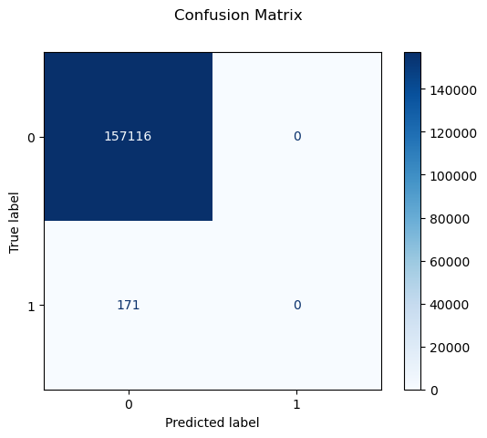

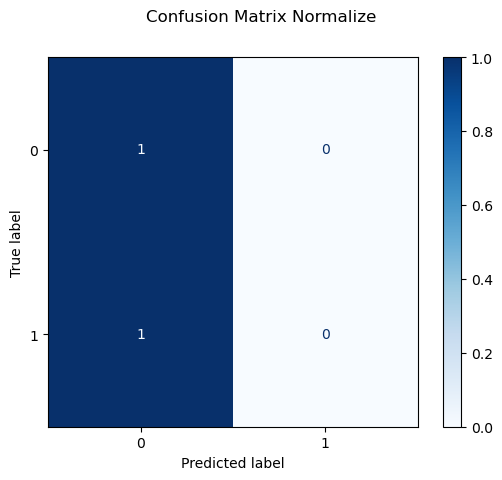

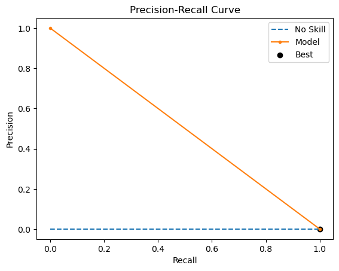

```
Model PR AUC: 0.5005435922867115
Best Threshold=0.000000, F-Score=0.002
```

```python
plot_metrics(yval, y_pred_dummy, yhat, Y)
```

As we advised in the Performance Metric Selection section, the accuracy of the dummy model is 99.89% but it does not penalize the false negatives. Hence, the F2 score, is 49.99%.

## Naive Bayes

```python
from sklearn.naive_bayes import GaussianNB

gnb = GaussianNB()
gnb = gnb.fit(xtrain, ytrain)
y_pred_gnb = gnb.predict(xval)
yhat= gnb.predict_proba(xval)
```

```
F2 Score: 0.5129328222170983

R2 Score: -49.29444542706853

Accuracy Score: 0.9453801013434041

              precision    recall  f1-score   support

           0       1.00      0.95      0.97    157116
           1       0.02      0.77      0.03       171

    accuracy                           0.95    157287
   macro avg       0.51      0.86      0.50    157287
weighted avg       1.00      0.95      0.97    157287
```

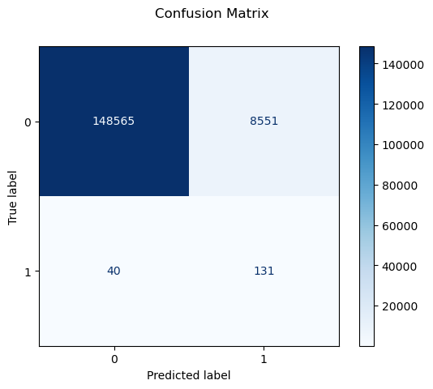

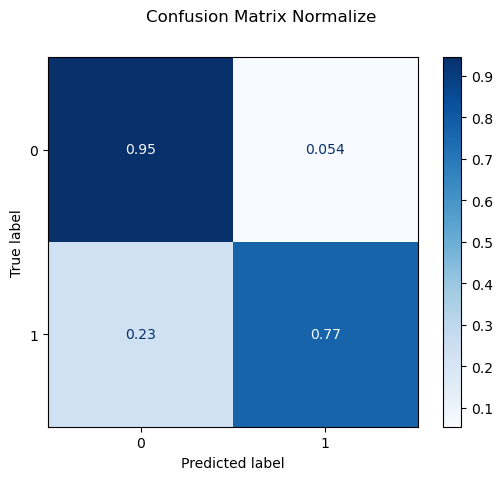

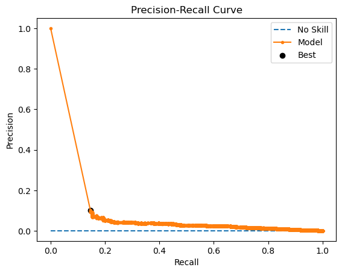

```
Model PR AUC: 0.10382441101094599
Best Threshold=1.000000, F-Score=0.120
```

```python
plot_metrics(yval, y_pred_gnb, yhat, Y)
```

Here, with the Naive Bayes, despite having less precission on the not frauds, for the fraud transactions the model predicts a 77% of the transactions. Hence, having a better F2 score than the previous model.

## Decision Tree Classifier

```python
dct = DecisionTreeClassifier()
dct = dct.fit(xtrain,ytrain)
y_pred_dct = dct.predict(xval)
yhat= dct.predict_proba(xval)
```

```
F2 Score: 0.8975494360407753

R2 Score: 0.5901977441631012

Accuracy Score: 0.9995549536833941

              precision    recall  f1-score   support

           0       1.00      1.00      1.00    157116
           1       0.80      0.80      0.80       171

    accuracy                           1.00    157287
   macro avg       0.90      0.90      0.90    157287
weighted avg       1.00      1.00      1.00    157287
```

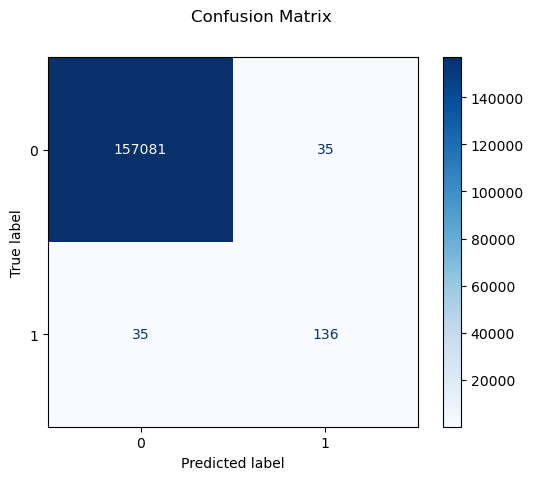

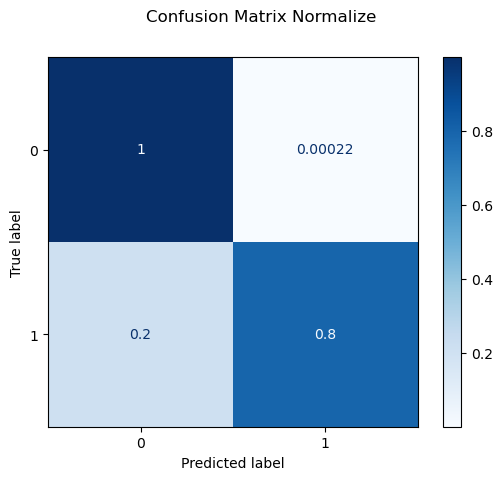

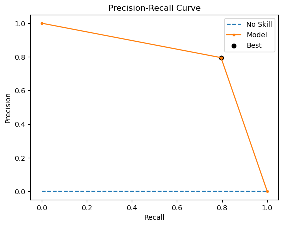

```
Model PR AUC: 0.795432899006052
Best Threshold=1.000000, F-Score=0.795
```

```python
plot_metrics(yval, y_pred_dct, yhat, Y)
```

We observe a considerable improvement, as the model correctly predicts 79% of the fraud cases. We will not perform further tests on the Decission Tree model.

## Random Forest Classifier

```python
rdm = RandomForestClassifier()
rdm = rdm.fit(xtrain, ytrain)
y_pred_rdm = rdm.predict(xval)
yhat= rdm.predict_proba(xval)
```

```
F2 Score: 0.8857706473378709

R2 Score: 0.7248470567952251

Accuracy Score: 0.9997011831874217

              precision    recall  f1-score   support

           0       1.00      1.00      1.00    157116
           1       0.99      0.73      0.84       171

    accuracy                           1.00    157287
   macro avg       1.00      0.87      0.92    157287
weighted avg       1.00      1.00      1.00    157287
```

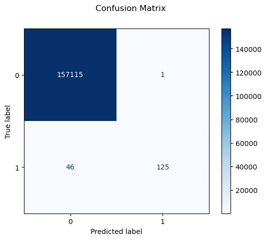

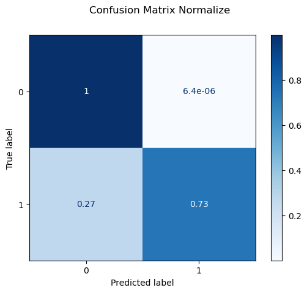

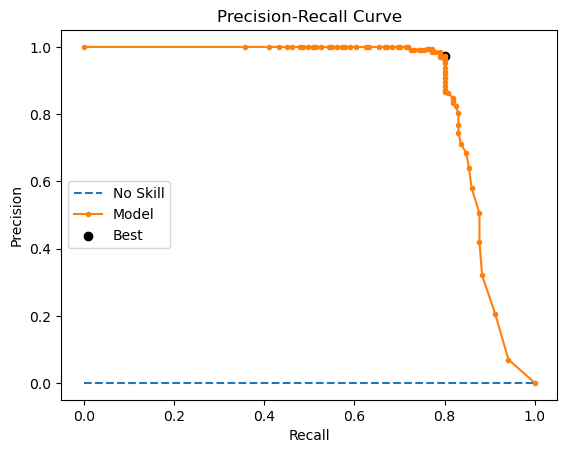

```
Model PR AUC: 0.8702173527781972
Best Threshold=0.310000, F-Score=0.878
```

```python
plot_metrics(yval, y_pred_rdm, yhat, Y)
```

Surprisingly, the Random Forest yields a worst result than the Decission Tree. We will not perform further tests on the Random Forest model.

## GLM

```python
import statsmodels.api as sm

glm = LogisticRegression()
glm = glm.fit(xtrain, ytrain)
y_pred_glm = glm.predict(xval)
yhat= glm.predict_proba(xval)
```

```
F2 Score: 0.5534696130738371

R2 Score: 0.08087208333724138

Accuracy Score: 0.9990018246898981

              precision    recall  f1-score   support

           0       1.00      1.00      1.00    157116
           1       0.94      0.09      0.16       171

    accuracy                           1.00    157287
   macro avg       0.97      0.54      0.58    157287
weighted avg       1.00      1.00      1.00    157287
```

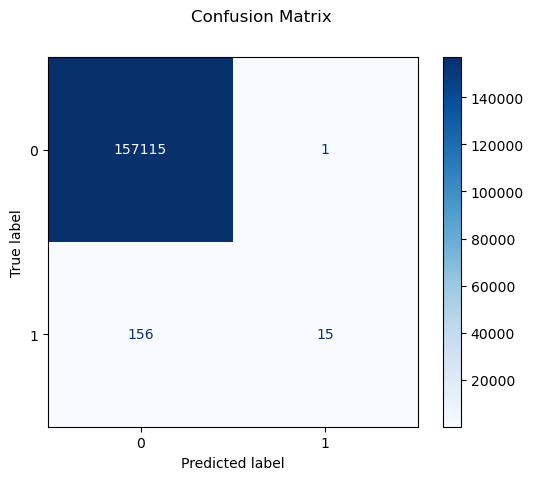

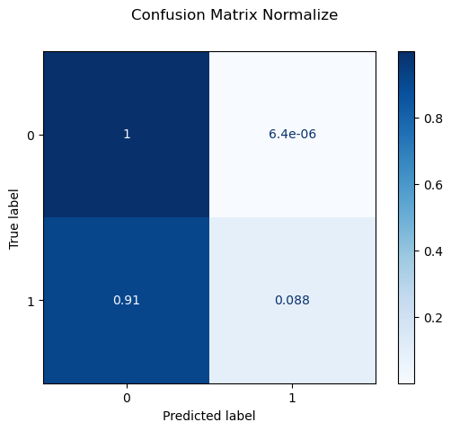

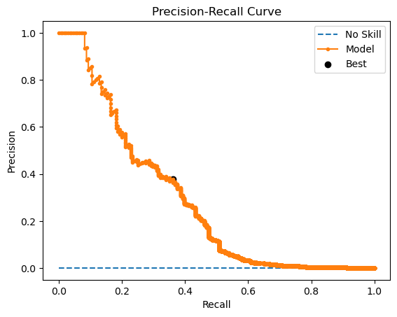

```
Model PR AUC: 0.2839178046794751
Best Threshold=0.034539, F-Score=0.370
```

```python
plot_metrics(yval, y_pred_glm, yhat, Y)
```

Due to its nature, the Generalized linear model yields a worst result, being the F2 score one of the worst. Hence, we will not perform further tests on the GLM model.

## XGBoost

```python
import xgboost

xgb = xgboost.XGBClassifier()

xgb = xgb.fit(xtrain, ytrain)

y_pred_xgb = xgb.predict(xval)
yhat= xgb.predict_proba(xval)
```

```
F2 Score: 0.9166424817308269

R2 Score: 0.7950988720815506

Accuracy Score: 0.999777476841697

              precision    recall  f1-score   support

           0       1.00      1.00      1.00    157116
           1       0.99      0.80      0.89       171

    accuracy                           1.00    157287
   macro avg       1.00      0.90      0.94    157287
weighted avg       1.00      1.00      1.00    157287
```

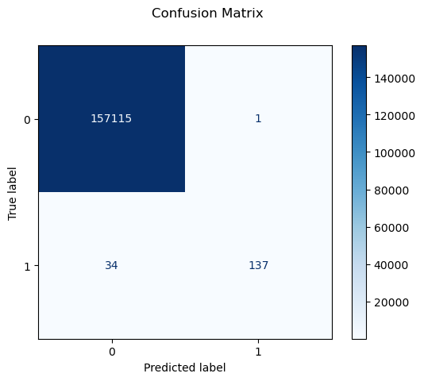

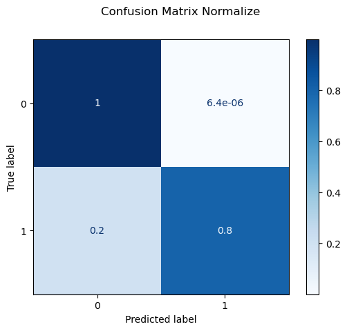

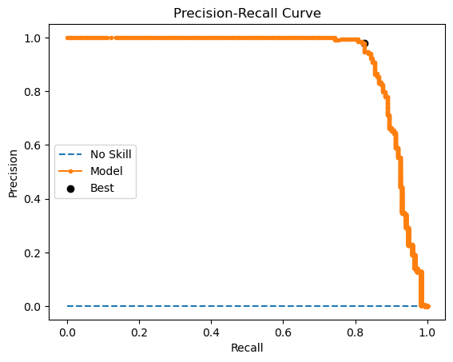

```
Model PR AUC: 0.9168376901300659
Best Threshold=0.396350, F-Score=0.895
```

```python
plot_metrics(yval, y_pred_xgb, yhat, Y)
```

A priori, the XGBoost is the best model so far. It only yields 1 false positive and 34 false negatives. On XGBoost we will perform further test with different hyperparameters.

## LightGBM

```python
import lightgbm

gbm = lightgbm.LGBMClassifier(n_estimators=180,
                              application= 'binary',
                              objective= 'binary',
                              metric= 'binary_logloss',
                              boosting='gbdt',
                              num_leaves= 50,
                              min_data_in_leaf= 200,
                              feature_fraction= 0.8,
                              bagging_fraction= 0.8,
                              learning_rate= 0.01,
                              max_depth= 12,
                              verbose=1,
                              random_state=seed)

gbm = gbm.fit(xtrain, ytrain)

y_pred_gbm = gbm.predict(xval)
yhat= gbm.predict_proba(xval)
```

[output not shown]

```
F2 Score: 0.8966522363773322

R2 Score: 0.7541186464978608

Accuracy Score: 0.9997329722100364

              precision    recall  f1-score   support

           0       1.00      1.00      1.00    157116
           1       1.00      0.75      0.86       171

    accuracy                           1.00    157287
   macro avg       1.00      0.88      0.93    157287
weighted avg       1.00      1.00      1.00    157287
```

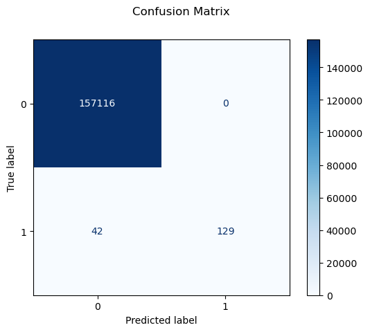

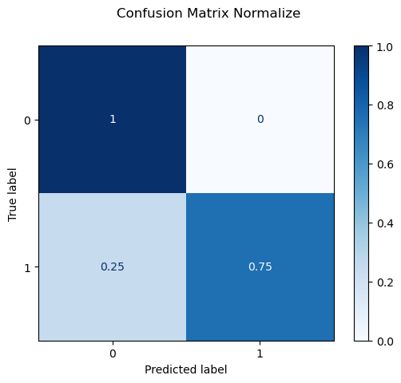

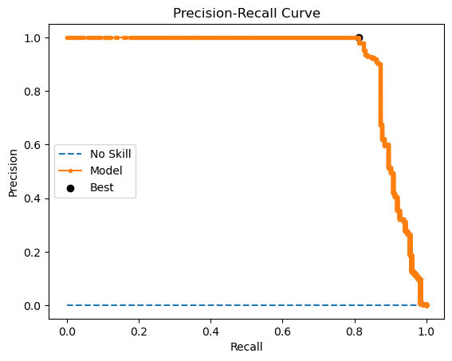

```
Model PR AUC: 0.9075306403601235
Best Threshold=0.212990, F-Score=0.897
```

```python
plot_metrics(yval, y_pred_gbm, yhat, Y)
```

## Logistic Regression + Lasso

```python
clf_LogisticLasso = LogisticRegression(penalty='l1', random_state=seed, solver='liblinear')
clf_LogisticLasso.fit(xtrain, ytrain)
```

```
LogisticRegression(penalty='l1', random_state=12345, solver='liblinear')
```

```python
sel_lasso = SelectFromModel(clf_LogisticLasso, threshold = 0.01)
sel_lasso.get_support()
selected_feat_lasso = xtrain.columns[sel_lasso.get_support()]
print('total features: {}'.format((xtrain.shape[1])))
print('selected features: {}'.format(len(selected_feat_lasso)))
selected_feat_lasso
```

```
total features: 17
selected features: 12
```

```
Index(['step', 'transactions_per_step', 'type', 'gender', 'device', 'age',
       'zone', 'user_number', 'amount', 'oldbalanceOrg', 'newbalanceOrig',
       'newbalanceDest'],
      dtype='object')
```

For the logistic regression performed, Lasso, that penalizes the amount of variables by increasing the cost function based on the variables features' weights, reduces the features to 12, without lossing accuracy

## AdaBoost

```python
ada = AdaBoostClassifier()

ada = ada.fit(xtrain, ytrain)

y_pred_ada = ada.predict(xval)
yhat= ada.predict_proba(xval)
```

```
F2 Score: 0.8307670837071695

R2 Score: 0.5550718365199385

Accuracy Score: 0.9995168068562564

              precision    recall  f1-score   support

           0       1.00      1.00      1.00    157116
           1       0.91      0.62      0.74       171

    accuracy                           1.00    157287
   macro avg       0.95      0.81      0.87    157287
weighted avg       1.00      1.00      1.00    157287
```

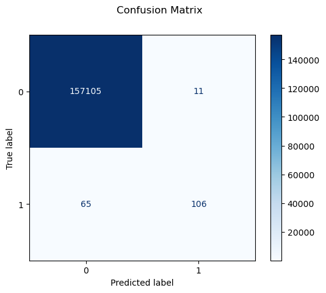

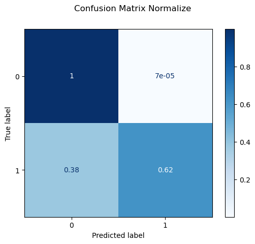

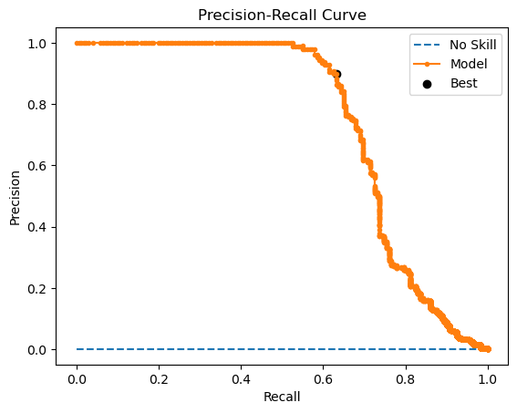

```
Model PR AUC: 0.7387789419644756
Best Threshold=0.499090, F-Score=0.742
```

```python
plot_metrics(yval, y_pred_ada, yhat, Y)
```

Yielding a worst result than some of the previous models, We will discard the AdaBoost model.

## GradientBoosting

```python
gbo = GradientBoostingClassifier()

gbo = gbo.fit(xtrain, ytrain)

y_pred_gbo = gbo.predict(xval)
yhat= gbo.predict_proba(xval)
```

```
F2 Score: 0.8703226376734731

R2 Score: 0.6663038773899539

Accuracy Score: 0.9996376051421924

              precision    recall  f1-score   support

           0       1.00      1.00      1.00    157116
           1       0.95      0.70      0.81       171

    accuracy                           1.00    157287
   macro avg       0.98      0.85      0.90    157287
weighted avg       1.00      1.00      1.00    157287
```

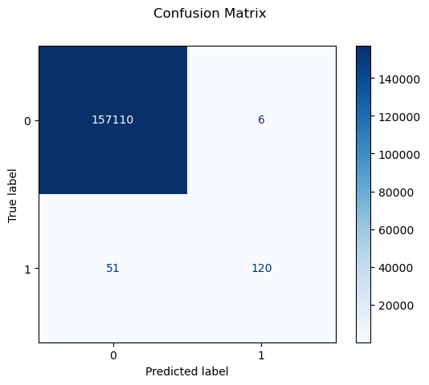

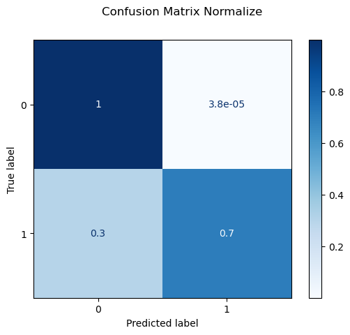

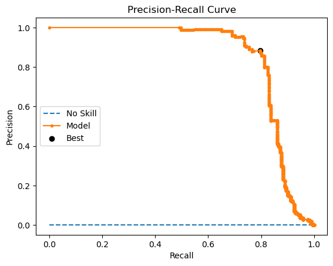

```
Model PR AUC: 0.8470567419247484
Best Threshold=0.185772, F-Score=0.837
```

```python
plot_metrics(yval, y_pred_gbo, yhat, Y)
```

Despite not being a bad model, again we have already models that perform better, hende we discard the Gradient Boosting

## KNeighbors

```python
from sklearn.neighbors import KNeighborsClassifier

knn = KNeighborsClassifier()

knn= knn.fit(xtrain, ytrain)

y_pred_knn = knn.predict(xval)

yhat= knn.predict_proba(xval)
```

```
F2 Score: 0.5252212553609813

R2 Score: 0.03989185775355153

Accuracy Score: 0.9989573200582375

              precision    recall  f1-score   support

           0       1.00      1.00      1.00    157116
           1       1.00      0.04      0.08       171

    accuracy                           1.00    157287
   macro avg       1.00      0.52      0.54    157287
weighted avg       1.00      1.00      1.00    157287
```

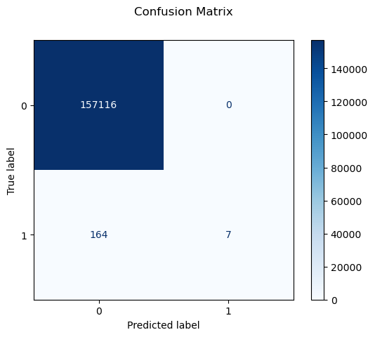

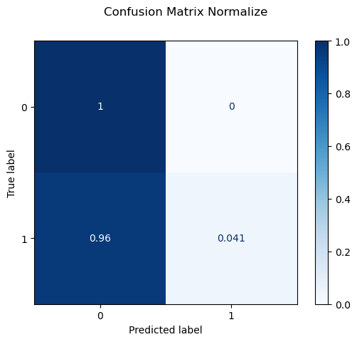

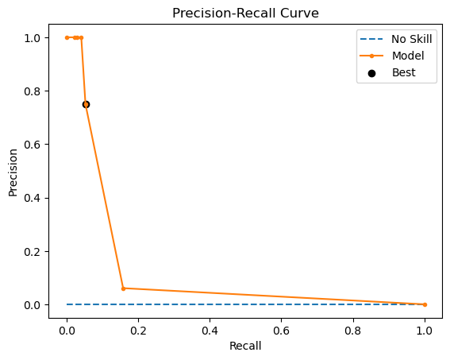

```
Model PR AUC: 0.12023423423779132
Best Threshold=0.400000, F-Score=0.098
```

```python
plot_metrics(yval, y_pred_knn, yhat, Y)
```

One of the worst models so far, since it fails on recognizing the fraud 96% of the cases. We will not perform further testing on the KNN model

## SVM

```python
from sklearn import svm

svm = svm.SVC()

svm = svm.fit(xtrain, ytrain)

y_pred_svm = svm.predict(xval)
```

```
F2 Score: 0.5500433602729331

R2 Score: 0.08087208333724138

Accuracy Score: 0.9990018246898981

              precision    recall  f1-score   support

           0       1.00      1.00      1.00    157116
           1       1.00      0.08      0.15       171

    accuracy                           1.00    157287
   macro avg       1.00      0.54      0.58    157287
weighted avg       1.00      1.00      1.00    157287
```

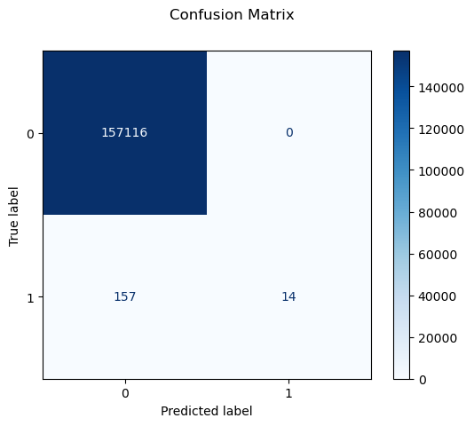

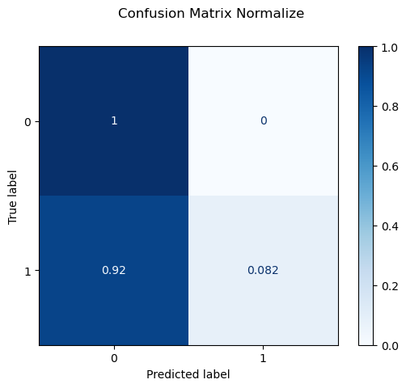

[figure not shown]

[output not shown]

```python
plot_metrics(yval, y_pred_svm, yhat, Y)
```

## Score Summary

```python
print("Modelo Base (dummy)")
print(f'\nF2 Score: {fbeta_score(yval, y_pred_dummy, beta=2, average="macro")}\n')# F2-Score

print("Naive Bayes")
print(f'\nF2 Score: {fbeta_score(yval, y_pred_gnb, beta=2, average="macro")}\n')# F2-Score

print("Decision tree classifer")
print(f'\nF2 Score: {fbeta_score(yval, y_pred_dct, beta=2, average="macro")}\n')# F2-Score

print("Random Forest Classifier")
print(f'\nF2 Score: {fbeta_score(yval, y_pred_rdm, beta=2, average="macro")}\n')# F2-Score

print("GLM")
print(f'\nF2 Score: {fbeta_score(yval, y_pred_glm, beta=2, average="macro")}\n')# F2-Score

print("XGBBoost")
print(f'\nF2 Score: {fbeta_score(yval, y_pred_xgb, beta=2, average="macro")}\n')# F2-Score

print("LightGBM")
print(f'\nF2 Score: {fbeta_score(yval, y_pred_gbm, beta=2, average="macro")}\n')# F2-Score

print("ADABOOST")
print(f'\nF2 Score: {fbeta_score(yval, y_pred_ada, beta=2, average="macro")}\n')# F2-Score

print("GRADIENTBOOSTING")
print(f'\nF2 Score: {fbeta_score(yval, y_pred_gbo, beta=2, average="macro")}\n')# F2-Score

print("KNeighbors")
print(f'\nF2 Score: {fbeta_score(yval, y_pred_knn, beta=2, average="macro")}\n')# F2-Score

print("SVM")
print(f'\nF2 Score: {fbeta_score(yval, y_pred_svm, beta=2, average="macro")}\n')# F2-Score
```

```
Modelo Base (dummy)

F2 Score: 0.49989118690272105

Naive Bayes

F2 Score: 0.5129328222170983

Decision tree classifer

F2 Score: 0.8975494360407753

Random Forest Classifier

F2 Score: 0.8857706473378709

GLM

F2 Score: 0.5534696130738371

XGBBoost

F2 Score: 0.9166424817308269

LightGBM

F2 Score: 0.8966522363773322

ADABOOST

F2 Score: 0.8307670837071695

GRADIENTBOOSTING

F2 Score: 0.8703226376734731

KNeighbors

F2 Score: 0.5252212553609813

SVM

F2 Score: 0.5500433602729331
```

Now, in the following notebook we will grid the main hiperparamerters of the XGBoost model and its explainability